# Lesperance eLowQuant LoD and LoQ: Stanford ddPCR

Zachary Gold

2026-04-08

```r
## Load the Data
FILE.PATH <- here("LOD_LOQ/pycno-fullSC-data-Stanford.csv")
DAT_RAW <- read.csv(FILE.PATH) %>% rename(SQ=TargetConcentration, Concentration=MeasuredConcentration) %>%
  mutate(SQ = na_if(SQ, 0)) %>%
  mutate(Concentration = na_if(Concentration, 0),
         PositiveDroplets = na_if(PositiveDroplets,0))
```

## Instructions

This file performs the computations in the publication, ‘A Statistical Model for Calibration and Computation of Detection and Quantification Limits for Low Copy Number Environmental DNA samples’ by Lesperance, Allison, Bergman, Hocking, Helbing, *Environmental DNA*, 2021, 00, 1-12 https://doi.org/10.1002/edn3.220. Code obtained from eLowQuant v20220912.

This code has been modified by Zachary Gold as a part of the manuscript Molecular Star Gazing: Development and Validation of an Environmental DNA Assay for the Imperiled Sunflower Sea Star (*Pycnopodia helianthoides*) to be able to handle both ddPCR and qPCR data. Since this method only requires binary data (0,1) for the model fitting, we apply the eLowQuant method to ddPCR calculations using the number of positive droplets. We recognize that in the ddPCR field there are multiple schools of thought on how to set a LoB and LoD. We include a parameter of minimum number of acceptable droplets (e.g. 1,2,3) as a detection.

### Process/Summarize samples by Lab; Compute the Poisson estimates of SQ

Hindson et al “High-Throughput Droplet Digital PCR System for Absolute Quantitation of DNA Copy Number”, Anal. Chem., 2011, 83 (22), pp 8604–8610 use a Poisson approximation for quantitation. Before that, Dube et al. 2008, “Mathematical analysis of copy number variation in a DNA sample using digital PCR on a nanofluidic device”, PloS One, Vol 3, Issue 8, e2876, model the number of molecules in each chamber as a Poisson process, giving the relationship between $p$ and $\lambda$.

```r
## Summarize data by (Target, SQ), detect=#detections, n=#tech reps
DAT.Tar.SQ <-  DAT.df %>%
  group_by(Target, SQ) %>%
  summarise(detect=sum(!is.na(Cq)), n=n(),  Cqmean=mean(Cq, na.rm=TRUE),
            Lab=Lab[1] )
DAT.Tar.SQ <- droplevels(data.frame(DAT.Tar.SQ))
#dim(DAT.Tar.SQ); cat('dim, before negative controls added')
#summary(DAT.Tar.SQ) %>% kable(digits=2)

uLabs <- unique(DAT.Tar.SQ$Lab) #unique labs

DAT.Tar.SQ <- arrange(DAT.Tar.SQ, Lab, Target, SQ) #sort data by SQ in Target in Lab

## Add variables to data set:  L10.SQ, phat, ...
DAT.Tar.SQ <- within(DAT.Tar.SQ, {
  L10.SQ <- log10(SQ)
  phat <- detect/n           #sample proportion detect
  vphat <- phat*(1-phat)/n   #var of phat
  lamhat <- -log(1-phat)
  vlamhat <- phat/n/(1-phat)  #var of lamhat using the delta method
  sdlamhat <- sqrt(vlamhat)   #sd of lamhat using the delta method
  MElamhat <- 1.96*sdlamhat  #margin of error for lambda hat using delta method
}
)



## All Targets and Labs **DO NOT DUPLICATE Target names over Labs!!
uLabs <- unique(DAT.Tar.SQ$Lab)
uTargets <- unique(DAT.Tar.SQ$Target)
nTargets <- length(uTargets)
uLabsTargets <- unique(DAT.Tar.SQ[,c('Lab','Target')])
uLabsTargets$Lab <- as.character(uLabsTargets$Lab)
#ensure ulabsTargets in same order as uTargets
uLabsTargets <- uLabsTargets[match(uLabsTargets$Target, uTargets),]
uLabsTargets.names <- apply(uLabsTargets, 1, paste, collapse=', ')

## Print summary tables.  If sink.indicator set to TRUE, writes tables to file.

knitr::kable(DAT.Tar.SQ, digits=3, caption=paste(uLabsTargets$Lab,uLabsTargets$Target), format = "markdown")
```

Stanford ddPCR PYCNO

| Target | SQ | detect | n | Cqmean | Lab | MElamhat | sdlamhat | vlamhat | lamhat | vphat | phat | L10.SQ |
| --- | --- | --- | --- | --- | --- | --- | --- | --- | --- | --- | --- | --- |
| PYCNO | 0e+00 | 0 | 8 | NaN | Stanford ddPCR | 0.000 | 0.000 | 0.000 | 0.000 | 0.000 | 0.000 | -Inf |
| PYCNO | 2e-01 | 1 | 8 | 1.000 | Stanford ddPCR | 0.262 | 0.134 | 0.018 | 0.134 | 0.014 | 0.125 | -0.699 |
| PYCNO | 4e-01 | 6 | 8 | 2.000 | Stanford ddPCR | 1.200 | 0.612 | 0.375 | 1.386 | 0.023 | 0.750 | -0.398 |
| PYCNO | 8e-01 | 7 | 8 | 2.000 | Stanford ddPCR | 1.833 | 0.935 | 0.875 | 2.079 | 0.014 | 0.875 | -0.097 |
| PYCNO | 1e+00 | 8 | 8 | 3.750 | Stanford ddPCR | Inf | Inf | Inf | Inf | 0.000 | 1.000 | 0.000 |
| PYCNO | 5e+00 | 8 | 8 | 20.000 | Stanford ddPCR | Inf | Inf | Inf | Inf | 0.000 | 1.000 | 0.699 |
| PYCNO | 1e+01 | 8 | 8 | 39.875 | Stanford ddPCR | Inf | Inf | Inf | Inf | 0.000 | 1.000 | 1.000 |
| PYCNO | 1e+02 | 8 | 8 | 413.500 | Stanford ddPCR | Inf | Inf | Inf | Inf | 0.000 | 1.000 | 2.000 |
| PYCNO | 1e+03 | 8 | 8 | 3545.375 | Stanford ddPCR | Inf | Inf | Inf | Inf | 0.000 | 1.000 | 3.000 |
| PYCNO | 1e+04 | 8 | 8 | 16700.250 | Stanford ddPCR | Inf | Inf | Inf | Inf | 0.000 | 1.000 | 4.000 |

```r
## Exact 95% Binomial Confidence intervals => backtransform given alpha and beta
## Binomial bound from Julious 2005, Stat in Medicine

DAT.Tar.SQ <- within(DAT.Tar.SQ, {
  CIexphat.lower <-  1 - qbeta(.975, n-detect+1, detect)  #exact phat bounds
  CIexphat.upper <-  qbeta(.975, detect+1, n-detect)

## Use transformed exact phat bounds
  Lamhatex.Lower <- -log(1 - CIexphat.lower)
  Lamhatex.Upper <- -log(1 - CIexphat.upper)
}
)
```

### Plot the Poisson estimates (and CI) of SQ for levels that had non-detects

Only the first levels of SQ that had non-detects are analyzed. Red line is least squares linear regression line.

LOOK AT THE GRAPHS IN THE CHUNK CALLED ‘PlotPois’ TO DETERMINE IF THE MODEL IS APPROPRIATE. IT IS NOT APPROPRIATE IF ‘lm Rsq’ is small, i.e. near zero!

*ML* will error if all phats==1

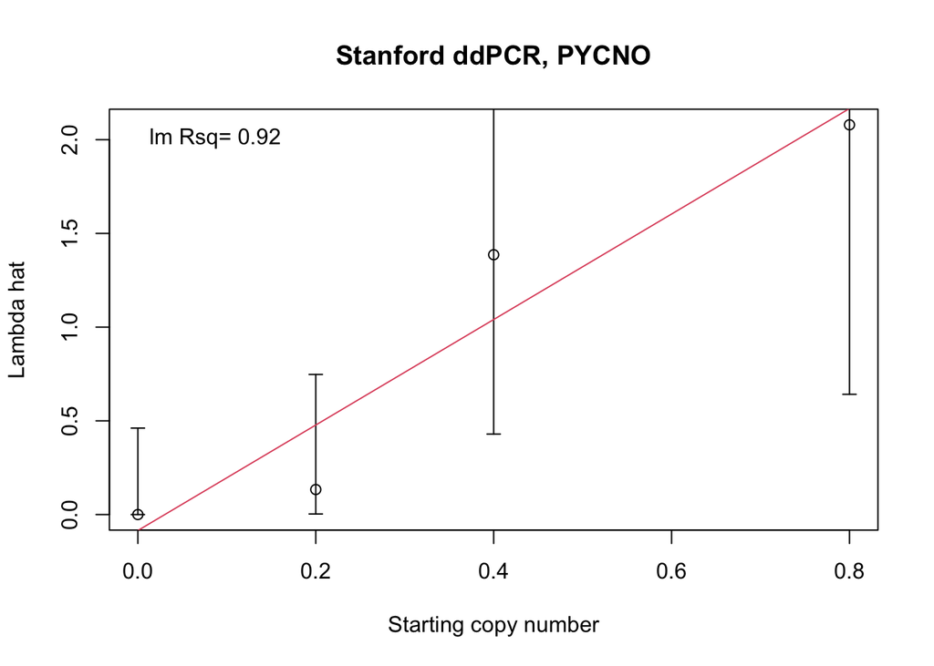

```r
## Use observations with nonempty data and where phat <1
## Only the SQ's before the first one with phat==1 are used
## Allows for variable numbers of SQ levels per Target

nndetect <- vector("list", nTargets)
nrowTarget <- rep(0, length=nTargets)

for(i in 1:nTargets) {
  Target.dat <- subset(DAT.Tar.SQ, Target==uTargets[i])
  bSQ <- !is.na(Target.dat$phat)
  lastSQ <- as.logical(cumprod(Target.dat$phat!=1 & bSQ))
## removes first observations with SQ with phat=1 and larger SQs
  Target.dat <- Target.dat[lastSQ,]
  nndetect[i] <- list(Target.dat )
  nrowTarget[i] <- nrow(Target.dat)

  if(nrow(nndetect[[i]]) < 2) {cat(paste('Too few values for ', uTargets[i])); next}

  maxSQ <- max(Target.dat$SQ)
  maxlamhat <- max(Target.dat$lamhat)
  plot(Target.dat$SQ, Target.dat$lamhat, xlog=TRUE, ylab='Lambda hat',
       xlab='Starting copy number',
       ylim=c(0, maxlamhat), xlim=c(0, maxSQ), main=uLabsTargets.names[i])
## Transformed Exact CI
  arrows(Target.dat$SQ, Target.dat$Lamhatex.Lower, Target.dat$SQ,
         Target.dat$Lamhatex.Upper,
         length=0.05, angle=90, code=3)
## overlay simple regression line and R-squared
  jlm <- lm(lamhat ~ SQ, data=Target.dat)
  abline(jlm, col=2)
  legend("topleft", paste('lm Rsq=',round(summary(jlm)$r.squared, 2)), bty="n")
  cat("\n\n")
}
```

Both the intercept and no intercept models are fit to the data. The ‘best’ of the two models is the one with the largest Likelihood Ratio test p-value. The ‘best’ model will be identified in the chunk called *Manuscript*.

## Intercept Model

### Estimate Poisson models - intercept model

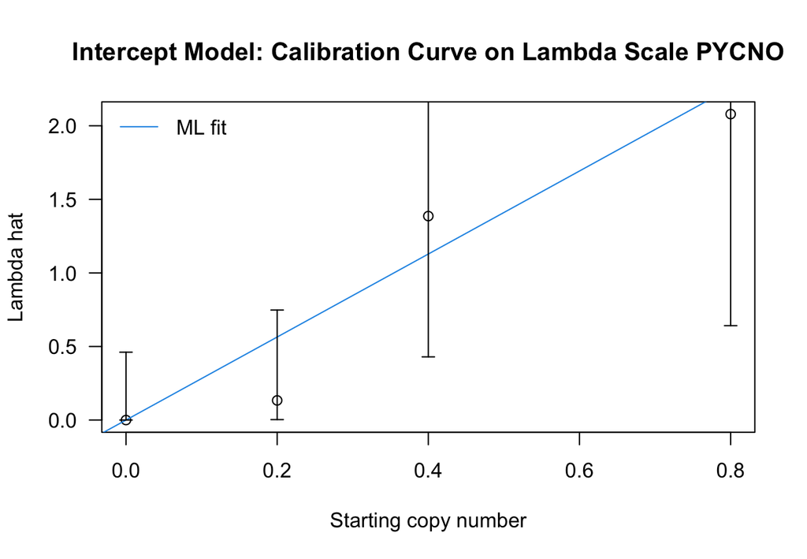

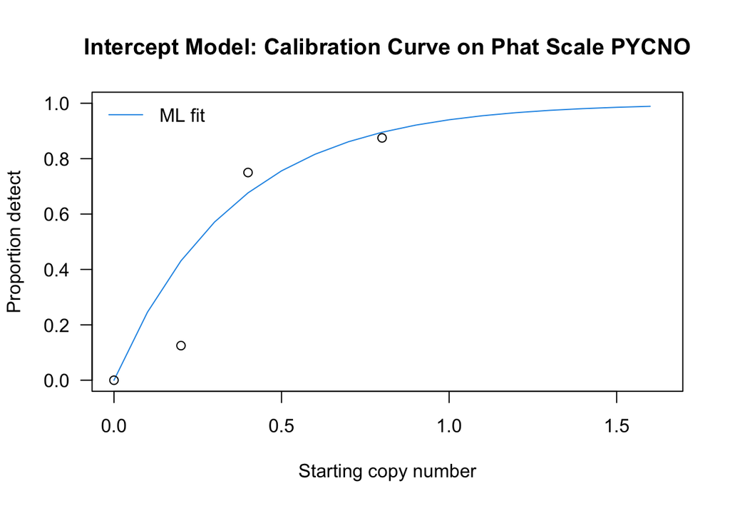

```
PYCNO
Convergence= 0
      Estimate  Std.Err Z value Pr(>z)
alpha 8.63e-11 8.04e-01    0.00   1.00
beta  2.82e+00 1.96e+00    1.44   0.15
LLR test stat= 3.794387 , df=  2 , p-value= 0.149989
```

```r
# List of results
Calib.fit.estimates <- vector("list", nTargets)  #list of fit estimates
names(Calib.fit.estimates) <- uTargets
Calib.fit.all <- vector("list", nTargets)  #list of fits all
Calib.fit.LLRp <- vector("numeric", nTargets)
names(Calib.fit.LLRp) <- uTargets
Calib.fit.res <- matrix(0, nrow=nTargets, ncol=4)
rownames(Calib.fit.res) <- uTargets
colnames(Calib.fit.res) <- c("convergence", "LLR", "degf","Pval")
Calib.fit.res <- data.frame(Calib.fit.res)

for(i in 1:nTargets){
  if(nrow(nndetect[[i]]) < 3) {Calib.fit.estimates[[i]] <- NULL
     cat(paste('Too few values for ', uTargets[i]), '\n')
    next}
  Target.dat <- nndetect[[i]]
  jlm <- lm(lamhat ~ SQ, data=Target.dat) #starting values for alpha and beta

  Calib.fit <- optim(par=pmax(c(0.01, 0.01), coef(jlm)), fn=Calib.LLik,
                     nd=Target.dat$detect,
                     S=Target.dat$SQ, nn=Target.dat$n, gr=Calib.dLLik,
                     method="BFGS", control=list(fnscale=-1),  hessian=TRUE)

  Calib.fit.all[[i]] <- Calib.fit
  if(nrow(Target.dat)==2) {
    Calib.fit.Var <- matrix(0, 2, 2)  #singular hessian for 2 observations
    }  else {
    Calib.fit.Var <- solve(-Calib.fit$hessian)
    }
  cmat <- cbind(Calib.fit$par, sqrt(diag(Calib.fit.Var)))
  cmat <- cbind(cmat, cmat[,1]/cmat[,2])
  cmat <- cbind(cmat, 2*pnorm(-cmat[, 3]))
  colnames(cmat) <- c("Estimate", "Std.Err", "Z value", "Pr(>z)")
  if (nrow(cmat)==1) {rownames(cmat) <- c("beta")
  } else  rownames(cmat) <- c("alpha","beta")
  Calib.fit.estimates[[i]] <- cmat

  #Likelihood ratio statistic and pvalue for goodnes-of-fit of the model
  Calib.degf <- nrow(Target.dat) - length(Calib.fit$par)
  Calib.LLR <- 2*(Bin.LLik(Target.dat$detect, Target.dat$n)
                  - Calib.fit$value)
  Calib.LLR.pv <- pchisq(Calib.LLR, Calib.degf, lower.tail = FALSE)
  Calib.fit.LLRp[i] <- Calib.LLR.pv
  Calib.fit.res[i,] <- c(Calib.fit$convergence, Calib.LLR, Calib.degf, Calib.LLR.pv)

  #Compute fitted values for ML model
  Calib.fitted <- Calib.fit$par[1] + Calib.fit$par[2]*  Target.dat$SQ

  # Plot calibration curve on lambda scale
  maxSQ <- max(Target.dat$SQ)
  maxlamhat <- max(Target.dat$lamhat)

  plot(Target.dat$SQ, Target.dat$lamhat, xlog=TRUE,
       ylab='Lambda hat', xlab='Starting copy number',
       ylim=c(0, maxlamhat), xlim=c(0, maxSQ),  las=1,
       main=paste0("Intercept Model: Calibration Curve on Lambda Scale ", uTargets[i]))
  abline(Calib.fit$par[1], Calib.fit$par[2], col=4)
  legend("topleft", legend=c('ML fit'), lty=1, col=4, bty="n")
  arrows(Target.dat$SQ, Target.dat$Lamhatex.Lower, Target.dat$SQ,
         Target.dat$Lamhatex.Upper,
         length=0.05, angle=90, code=3)

  # Plot calibration curve on phat scale
  # Compute minSQ such that phat~=1
  maxSQa <-max( -(Calib.fit$par[1] + log(.01))/Calib.fit$par[2], maxSQ)
  sqs <- seq(0, maxSQa, by=.1)
  Calib.phat <- 1 - exp(-(Calib.fit$par[1] + Calib.fit$par[2] * sqs))

  plot(sqs, Calib.phat, xlog=TRUE,
       ylab='Proportion detect', xlab='Starting copy number', type='l', col=4, las=1,
       ylim=c(0, 1), xlim=c(0, maxSQa),  main=paste0("Intercept Model: Calibration Curve on Phat Scale ", uTargets[i]))
  points(Target.dat$SQ, Target.dat$phat)
  legend("topleft", legend=c('ML fit'), lty=1, col=4, bty="n")

  cat(as.character(uTargets[i]), "\n")
  cat("Convergence=", Calib.fit$convergence, "\n")
  printCoefmat(cmat, digits=3)
  cat('LLR test stat=', Calib.LLR, ', df= ', Calib.degf, ', p-value=', Calib.LLR.pv, "\n\n")

}
```

**Convergence of 0 indicates a successful model fit**

### Estimate predicted Sq given consecutive numbers of detects given number of technical replicates - intercept model

The estimated SQ is easily obtained for given new values of nn0=number of replicates, nd0=number detected and the estimated slope betaS as: Shat <- -(log((nn0 - nd0)/nn0) + betaS[1]) / betaS[2] The standard errors are obtained from the Hessian matrix (or via the function CalibS0.ddLLik()).

```r
  #Calibration estimate of S0 given new nd0=number detected, nn0=number replicates
  # includes standard errors

  CalibS0.table <- vector("list", nTargets)  #list of fits including test value

  for(i in 1:nTargets){
   nn0 <- 8  #test number technical replicates, greater than 1
#  nn0 <- 3
#  nn0 <- 24

     if(nrow(nndetect[[i]]) < 3) {CalibS0.table[[i]] <- NULL
     cat(paste('Too few values for ', uTargets[i]), '\n')
     next}

  Target.dat <- nndetect[[i]]
  SQS0.fit <- matrix(0, ncol=6, nrow=0)

  for(nd0 in 0:(nn0-1)){

   jlm <- lm(lamhat ~ SQ, data=Target.dat) #starting values for alpha and beta
   jpar <- pmax(c(0.01, 0.01), coef(jlm))
   Stilde <- -(log((nn0 - nd0)/nn0) + jpar[1]) / jpar[2]

   CalibS0.fit <- optim(par=c(jpar, Stilde),
                       fn=CalibS0.LLik,  nd=Target.dat$detect,
                       S=Target.dat$SQ, nn=Target.dat$n, nd0=nd0, nn0=nn0,
                       control=list(fnscale=-1), method="BFGS",
                       gr=CalibS0.dLLik, hessian=TRUE)

  CalibS0.fit.Var <- solve(-CalibS0.fit$hessian)
  betaS <- CalibS0.fit$par
  cvec <- as.vector(rbind(betaS, sqrt(diag(CalibS0.fit.Var))))
  SQS0.fit <- rbind(SQS0.fit, cvec)
  }

  rownames(SQS0.fit) <- paste(1:nrow(SQS0.fit))
  colnames(SQS0.fit) <- c("alpha", "SEalpha", "beta","SEbeta", "SQ0","SE_SQ0")

  #Negative SQ0 values can occur when there are detects for negative controls
  # set SQ0 and SE_SQ0 to zero
  SQS0.fit[ SQS0.fit[,5] < 0, 5:6] <- 0


  }


  cat("\n",as.character(uTargets[i]), "\n")
```

```
 PYCNO
```

```r
  cat(' ML estimate of SQ for numbers of detects and', nn0, 'replicates', '\n')
```

```
 ML estimate of SQ for numbers of detects and 8 replicates
```

```r
  knitr::kable(cbind(NumDetects=0:(nn0-1), SQS0.fit[,5:6]),
                     format="pandoc", digits=3)
```

| NumDetects | SQ0 | SE_SQ0 |
| --- | --- | --- |
| 0 | 0.000 | 0.000 |
| 1 | 0.046 | 0.287 |
| 2 | 0.101 | 0.242 |
| 3 | 0.166 | 0.214 |
| 4 | 0.245 | 0.197 |
| 5 | 0.349 | 0.205 |
| 6 | 0.492 | 0.264 |
| 7 | 0.736 | 0.435 |

```r
  CalibS0.table[[i]] <- SQS0.fit
```

# LOB, LOD, LOQ Calculations

Follows Lavagnini and Magno 2007, Mass Spectrometry Reviews *The notation in the paper was changed from the Lavagnini 2007 paper and is shown in brackets here.*

- Lc (*LOB Limit of blank*) = critical level is the assay signal above which a response is reliably attributed to the presence of analyte
- Ld (*Ld = expected number detects out of NN replicates at concentration LOD*) = signal corresponding to an analyte concentration xd (*=LOD Limit of Detection*) level which may be a priori expected to be recognized
- Lq = quantification limit is a signal with a precision which satisfies an expected value ($=\gamma_Q$)

Lc corresponds to a critical response level or a false positive rate, i.e. critical number of detects given NN replicates, above which we would reject the null hypothesis that the concentration/copy number is zero at alpha = alphaLc ($=\gamma_{FP}$). It is the critical response level corresponding to the false positive rate of alphaLc. Essentially, the test is positive if the Y~Binomial(m, p) > Lc. The False Positive Rate is P(Y > Lc | S=0).

Ld is computed to correspond to the false negative rate, beta = betaLd ($=\gamma_{FN}$) here. It is computed so that the probability of observing a new (unknown concentration) response less than or equal to Lc is less than or equal to betaLd. The probability of observing Lc or less detects if the concentration is xd (*=LOD Limit of Detection*) or more is less than or equal to betaLd. The values of Lc depend on the number of replicates, NN, so xd does as well. Ld is the expected number of detects at values xd (*=LOD Limit of Detection*) and NN replicates. False negative rate Ld computation: P(Y <= Lc | p_xd) <= betaLd, ($=\gamma_{FN}$) and solve for xd (*=LOD Limit of Detection*).

Lq is less well defined. The literature suggests using Lq = beta0 + 10 s.e.(beta0), but this uses the normality assumption. Other literature suggests using the “analyte concentration xq (*=LOQ Limit of Quantification*) for which the experimental relative standard deviation of the responses reaches a fixed level ($=\gamma_Q$), for example, the level 0.1.” Lavagnini and Magno 2007. I interpret the term “relative standard deviation” to mean the coefficient of variation, CV = sd/mean.

In the exercise below, we use the fits from the ML models to estimate the Lc, Ld and Lq, for various values of NN replicates for a new observation, i.e. a new (unknown concentration) response number of detects. Both the intercept and no intercept models are considered.

### Determine Lc, Ld, Lq (LOB, LOD and LOQ) - intercept model

```r
# Lc computation:  P(Y > Lc | S=0) <= alphaLc - intercept model computations
#  where Y ~ Bin(m, p=1 - exp(-betas[1]))
#  to incorporate estimation uncertaintly in betas[1], use upper limit of conf int
#  i.e. Y ~ Bin(m, p=1 - exp(-(betas[1] + 1.96 * s.e.(betas[1])))
# Ld computation:  P(Y <= Lc | p_xd) <= betaLd
#  use relationship between Binomial and Beta distribution, p 278 Bain
# Lq computation:  (Forootan 2017)  choose level, Sj, such that CV<=gammaLq
#  not clear which scale: response, back-transformed values, ... ?
#
##* Note in R:  The quantile is defined as the smallest value x such
##    that F(x) ≥ p, where F is the distribution function.

## Set values for alphaLC, betaLd, gammaLq
alphaLc <- betaLd <- .05; gammaLq <- .20
NN <- c(3, 8, 16, 24, 32, 48, 64, 96)  #test number of replicates

#set up tables for manuscript output
Lc.all <- matrix(0, nrow=nTargets, ncol=length(NN))
row.names(Lc.all) <-  uTargets
colnames(Lc.all) <-  paste(NN)
Lc.upper.all <- xd.all <- xd_upper.all <- xd_lower.all <-
  xq.all <- xq_lower.all <- xq_upper.all <- Lc.all

for(i in 1:nTargets){
  #use beta estimated from fits above
     if(nrow(nndetect[[i]]) < 3) {
     cat(paste('Too few values for ', uTargets[i]), '\n')
     next}

  betas <- (Calib.fit.estimates[[i]])[,1]

  #ML Takes into account uncertainty in new observation and s.e. of betas
  betas.upper <- betas + 1.96 * (Calib.fit.estimates[[i]])[,2]
  betas.lower <- pmax(0, betas - 1.96 * (Calib.fit.estimates[[i]])[,2]) +0.01

  #Want: P(Y > Lc | S=0) <= alphaLc where Y ~ Bin(m, p=1 - exp(-betas[1]))
  #Lc at xc=0 values for new observation
  p.new <- 1 - exp(-betas[1])
  Lc.new <- qbinom(1 - alphaLc, size=NN, prob=p.new)
  names(Lc.new) <- paste(NN)
  Lc.all[i,] <- Lc.new

  #Lc.upper at xc=0 values for new observation, incl s.e. of betas
  p.upper <- 1 - exp(-betas.upper[1])
  Lc.upper <- qbinom(1 - alphaLc, size=NN, prob=p.upper)
  names(Lc.upper) <- paste(NN)
  Lc.upper.all[i,] <- Lc.upper

  #Want xd, P(Y <= Lc | p_xd) <= betaLd
  #Ld and xd calculation
  pxd <- 1 - qbeta(betaLd, NN-Lc.new, Lc.new+1)   #proportion detected
  Ld <- NN * pxd
  xd <- (-betas[1] - log(1 - pxd)) / betas[2]   #concentration
  names(pxd) <- names(xd) <- paste(NN)

  # pxd_upper <- 1 - qbeta(betaLd, NN-Lc.upper, Lc.upper+1)   #proportion detected\
  # Ld_upper <- NN * pxd_upper
  # xd_upper <- (-betas[1] - log(1 - pxd_upper)) / betas[2]   #concentration
  xd_lower <- pmax(0, (-betas.upper[1] - log(1 - pxd)) / betas.upper[2])
  xd_upper <- (-betas.lower[1] - log(1 - pxd)) / betas.lower[2]
  names(xd_upper) <- names(xd_lower) <- paste(NN)

  xd.all[i,] <- xd
  xd_upper.all[i,] <- xd_upper
  xd_lower.all[i,] <- xd_lower

  #Compute model based xq
  xq <- -(betas[1] + log(1 - 1/(1 + gammaLq^2*NN)))/betas[2]
  names(xq) <- paste(NN)

  #Compute model based xq using lower estimates of beta
  xq_lower <- -(betas.lower[1] + log(1 - 1/(1 + gammaLq^2*NN)))/betas.lower[2]
  names(xq_lower) <- paste(NN)

  #Compute model based xq using upper estimates of beta
  xq_upper <- -(betas.upper[1] + log(1 - 1/(1 + gammaLq^2*NN)))/betas.upper[2]
  names(xq_upper) <- paste(NN)


  xq.all[i,] <- xq
  xq_lower.all[i,] <- xq_lower
  xq_upper.all[i,] <- xq_upper


  }



#For a given p_hat, one can compute the sample size m required to attain a
#  CV  <= gammaLq, as   m >= (1-phat)/(phat*gammaLq)
```

### Estimates, Lc, Ld, Lq (LOB, LOD, LOQ) and confidence limits for a given number of technical reps NN[NNi]

Chooses the model (intercept versus no intercept) with the best LLR test fit, i.e. the largest p-value for the LLR test. A table of values for all assays is printed.

```r
# Set the index into NN which is defined in chunk LcLdLqNN0 and LcLdLqNN
# NNi <- 2 corresponds to the 2nd entry of NN
NNi <- 2

#cat('Limits intercept model for N=', NN[NNi])
xdxq.all <- cbind(Lc=Lc.all[,NNi],
                  # LcUp=Lc.upper.all[,NNi],
                   SdLow=xd_lower.all[,NNi],
                   Sd=xd.all[,NNi], SdUp=xd_upper.all[,NNi],
                   SqLow=xq_upper.all[,NNi],
                   Sq=xq.all[,NNi], SqUp=xq_lower.all[,NNi])


#Include alpha and beta estimates in table
alphabeta.se <- alphabeta0.se  <- matrix(0, nrow=nTargets, ncol=4)
colnames(alphabeta.se) <- c("alpha","aSE", "beta", "bSE")
colnames(alphabeta0.se) <- c("alpha","aSE", "beta", "bSE")
rownames(alphabeta0.se) <- rownames(alphabeta.se) <- uTargets

for (i in 1:nTargets){
  if(nrowTarget[i]>2){
  alphabeta.se[i,1:2] <- Calib.fit.estimates[[i]][1, 1:2]
  alphabeta.se[i, 3:4] <- Calib.fit.estimates[[i]][2, 1:2]
  }
}



Calib.choice <- Calib.fit.LLRp
xdxq.choice <- cbind(InterModel=Calib.choice, alphabeta.se, xdxq.all)
xdxq.choice[Calib.choice, 6:12] <- xdxq.all[Calib.choice,]
xdxq.choice[Calib.choice, 2:5] <- alphabeta.se[Calib.choice,]

# NNi <- 2 This is set above
cat('Limits for best choice model for N=', NN[NNi], '\n')
```

```
Limits for best choice model for N= 8
```

```r
print(round(xdxq.choice[nrowTarget > 2,], digits=2))
```

```
InterModel      alpha        aSE       beta        bSE         Lc      SdLow
      0.15       0.00       0.80       2.82       1.96       0.00       0.00
        Sd       SdUp      SqLow         Sq       SqUp
      0.13      36.45      -0.02       0.50     140.71
```

### Tables and Graphs for the manuscript

*Revised for general use to use all eligible targets.*

### Intercept model Results: Estimates, Critical, Detection, Quantification Limits and CIs

```r
xdxq.all.PR <- cbind(alphabeta.se, xdxq.all)
xdxq.all.PR <- xdxq.all.PR[nrowTarget>2, , drop=FALSE]
xdxq.all.PR <- xdxq.all.PR[order(row.names(xdxq.all.PR)), , drop=FALSE]
colnames(xdxq.all.PR)[5:11] <- c('LOB','LODL','LOD','LODU','LOQL','LOQ','LOQU')
knitr::kable(round(xdxq.all.PR,
                    digits=1),
                    format="pandoc", digits=1,
                     results="asis")
```

|  | alpha | aSE | beta | bSE | LOB | LODL | LOD | LODU | LOQL | LOQ | LOQU |
| --- | --- | --- | --- | --- | --- | --- | --- | --- | --- | --- | --- |
| PYCNO | 0 | 0.8 | 2.8 | 2 | 0 | 0 | 0.1 | 36.4 | 0 | 0.5 | 140.7 |

#### Underlying Data

```r
Targeti <-1
  jmat <- nndetect[[Targeti]][, c(2:4, 12, 10)]
  row.names(jmat) <- NULL
  names(jmat) <- c("S", "num.detect", "n", "p.tilde", "lambda.tilde")
  knitr::kable(jmat,
                     format="pandoc", digits=3, caption=uTargets[Targeti])
```

PYCNO

| S | num.detect | n | p.tilde | lambda.tilde |
| --- | --- | --- | --- | --- |
| 0.0 | 0 | 8 | 0.000 | 0.000 |
| 0.2 | 1 | 8 | 0.125 | 0.134 |
| 0.4 | 6 | 8 | 0.750 | 1.386 |
| 0.8 | 7 | 8 | 0.875 | 2.079 |

#### Intercept Model

```r
#V20220912 printed all output results

# Print regression outputs
#  if (Calib.choice[Targeti]){
  cat("\n", as.character(uTargets[Targeti]), "\n")
```

```
 PYCNO
```

```r
  cat("Convergence=", Calib.fit.res$convergence[Targeti], "\n")
```

```
Convergence= 0
```

```r
  printCoefmat(Calib.fit.estimates[[Targeti]], digits=3)
```

```
      Estimate  Std.Err Z value Pr(>z)
alpha 8.63e-11 8.04e-01    0.00   1.00
beta  2.82e+00 1.96e+00    1.44   0.15
```

```r
  cat('LLR test stat=', Calib.fit.res$LLR[Targeti], ', df= ',
      Calib.fit.res$degf[Targeti], ', p-value=', Calib.fit.res$Pval[Targeti], "\n\n")
```

```
LLR test stat= 3.794387 , df=  2 , p-value= 0.149989
```

**Convergence of 0 demonstrates successful model run**

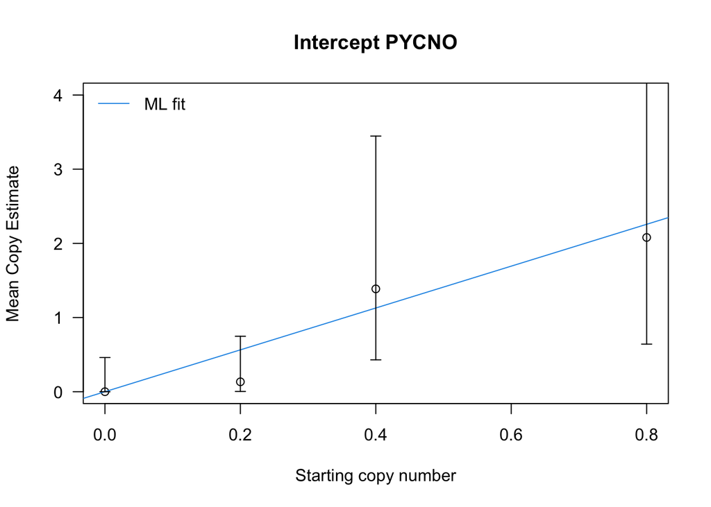

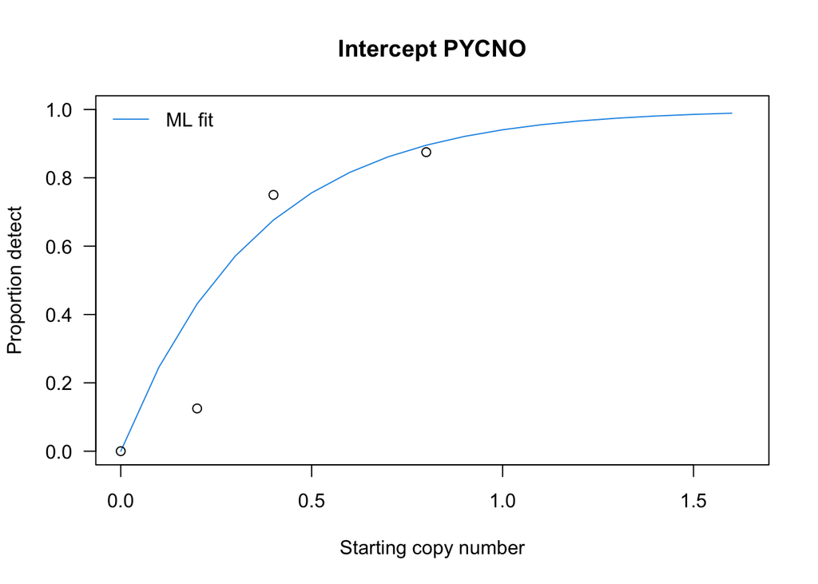

```r
# Plots of fits using chosen no-intercept/intercept model
#V20220912 plotted all output results

for(Targeti in ManuTargets){
  Target.dat <- nndetect[[Targeti]]

#  if (Calib.choice[Targeti]){
  Calib.fit <- Calib.fit.all[[Targeti]]
  Calib.fitted <- Calib.fit$par[1] + Calib.fit$par[2]*  Target.dat$SQ

  # Plot calibration curve on lambda scale
  maxSQ <- max(Target.dat$SQ)
  maxlamhat <- max(Target.dat$lamhat)

  plot(Target.dat$SQ, Target.dat$lamhat, xlog=TRUE,
       ylab='Mean Copy Estimate',
       xlab='Starting copy number',
       ylim=c(0, 4), xlim=c(0, maxSQ), las=1,
#      ylim=c(0, maxlamhat), xlim=c(0, maxSQ), las=1,
       main=paste('Intercept',uTargets[Targeti]))
  abline(Calib.fit$par[1], Calib.fit$par[2], col=4)
  legend("topleft", legend=c('ML fit'), lty=1, col=4, bty="n")
  arrows(Target.dat$SQ, Target.dat$Lamhatex.Lower, Target.dat$SQ,
         Target.dat$Lamhatex.Upper,
         length=0.05, angle=90, code=3)

  # Plot calibration curve on phat scale
  # Compute minSQ such that phat~=1 (1-phat = .99)
  maxSQa <-max( -(Calib.fit$par[1] + log(.01))/Calib.fit$par[2], maxSQ)
  sqs <- seq(0, maxSQa, by=.1)
  Calib.phat <- 1 - exp(-(Calib.fit$par[1] + Calib.fit$par[2] * sqs))

  plot(sqs, Calib.phat, xlog=TRUE,
       ylab='Proportion detect', xlab='Starting copy number', type='l', col=4, las=1,
       ylim=c(0, 1), xlim=c(0, maxSQa),  main=paste('Intercept',uTargets[Targeti]))
  points(Target.dat$SQ, Target.dat$phat)
  legend("topleft", legend=c('ML fit'), lty=1, col=4, bty="n")
}
```

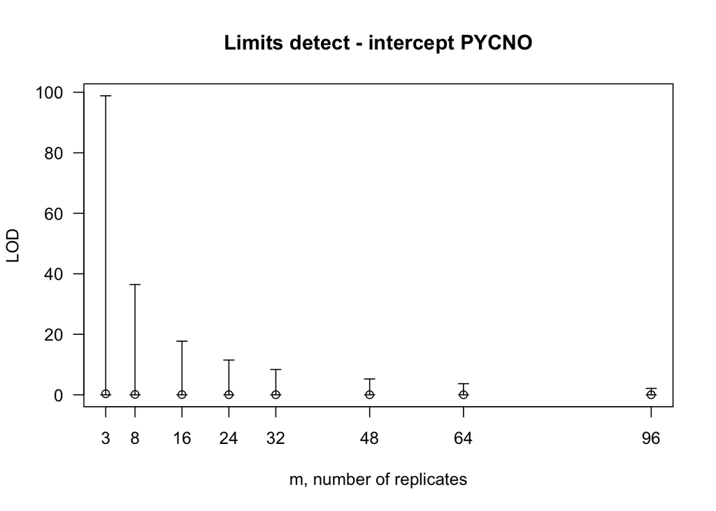

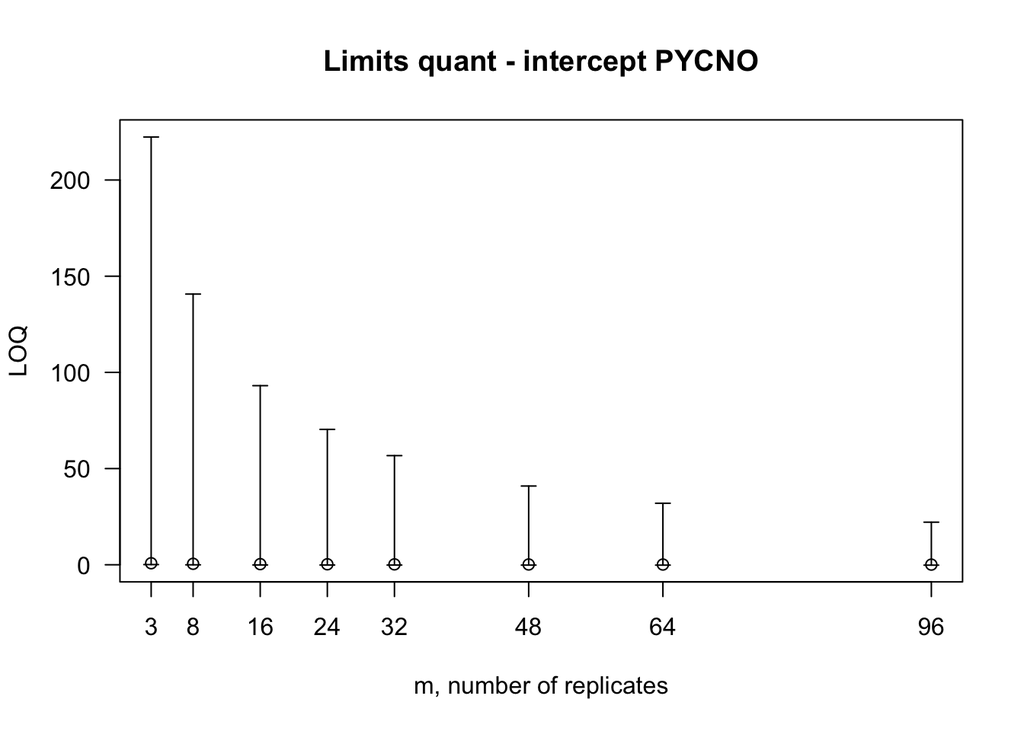

```r
# Plot limits of detection
# Note:  the same vertical scale is used for all assays
#V20220912 plotted all output results

max.xd_upper <- max(xd_upper.all[ManuTargets,])

for(Targeti in ManuTargets){
#max.xq_lower <- max(xq_lower.all[Targeti,])

#  if (Calib.choice[Targeti]){
  plot(NN, xd.all[Targeti,], ylab='LOD',
       xlab='m, number of replicates', xaxt='n',
       ylim=c(0, max.xd_upper), xlim=c(min(NN), max(NN)),  las=1,
       main=paste('Limits detect - intercept', uTargets[Targeti]))
#        main=uTargets[Targeti])
  axis(1, at=NN)

  # Transformed Exact CI
  arrows(NN, xd_lower.all[Targeti,], NN,
        xd_upper.all[Targeti,],
         length=0.05, angle=90, code=3)


#}

# Plots limits of Quantification
# Note:  the same vertical scale is used for all assays
#V20220912 plotted all output results

max.xq_lower <- max(xq_lower.all[ManuTargets,])

for(Targeti in ManuTargets){

#  if (Calib.choice[Targeti]){
  plot(NN, xq.all[Targeti,], ylab='LOQ',
       xlab='m, number of replicates', xaxt='n',
       ylim=c(0, max.xq_lower), xlim=c(min(NN), max(NN)),  las=1,
       main=paste('Limits quant - intercept', uTargets[Targeti]))
#        main=uTargets[Targeti])
  axis(1, at=NN)

  # Transformed Exact CI
  arrows(NN, xq_upper.all[Targeti,], NN,
        xq_lower.all[Targeti,],
         length=0.05, angle=90, code=3)

  }
}
```